# Aidan_Borkan_MiniProject2

Aidan Borkan

2024-03-15

#load our libraries

```r
library(bigrquery)
library(DBI)
library(dplyr)
```

```r
library(ggplot2)
library(caret)
```

#we need to connect to Google Big Query #Training Data: #Gold standard data from manual record review is available on Google #BigQuery in the “course3_data.hypertension_goldstandard” table.

```r
con <- DBI::dbConnect(drv = bigquery(),
                      project = "learnclinicaldatascience")
```

#lets extract into a variable called data #* for all

```r
data <- dbGetQuery(con, "SELECT * FROM `learnclinicaldatascience.course3_data.hypertension_goldstandard`")
```

```
## ! Using an auto-discovered, cached token.
```

```
##   To suppress this message, modify your code or options to clearly consent to
##   the use of a cached token.
```

```
##   See gargle's "Non-interactive auth" vignette for more details:
```

```
## ℹ The bigrquery package is using a cached token for 'aidanborkan@gmail.com'.
```

#clinical background #What is Hypertension?

● Systolic BP >= 140 mmHg on more than two occasions ● Diastolic BP>= 90 mmHg on more than two occasions

#Billing #How is Hypertension billed?

#Multiple Codes for Essential Hypertension:

● 401.0 Malignant ● 401.1 Benign ● 401.9 Unspecified

#In addition to diet and exercise there are a number of blood pressure lowering drugs available. Many of these drugs have uses beyond treating hypertension and in fact may be used for non-hypertensive indications more frequently than hypertension. A quasi exhaustive list of these therapies as they are referred to by MIMIC records can be found on GBQ in course3_data. D_ANTIHYPERTENSIVES.

#let’s extract the list of therapies from mimic records into a variable called therapies

```r
therapies_table <- tbl(con, "course3_data.D_ANTIHYPERTENSIVES")
therapies <- therapies_table %>%
  select(DRUG) %>%  # Adjust 'THERAPY' if the column name is different
  distinct() %>%
  collect()

# View the therapies
print(therapies)
```

```
## # A tibble: 166 × 1
##    DRUG
##    <chr>
##  1 Lasix
##  2 Lotrel
##  3 Tiazac
##  4 Nadolol
##  5 Timolol
##  6 Zestril
##  7 timolol
##  8 Atenolol
##  9 Bosentan
## 10 Losartan
## # ℹ 156 more rows
```

```r
## getStats(df, predicted, reference)

getStats <- function(df, predicted, reference) {
  df %>%
    select({{ predicted }}, {{ reference }}) %>%
    mutate_all(~ factor(., levels = c(1, 0))) %>%
    table() %>%
    caret::confusionMatrix()
}
```

#how many unique SUBJECT_IDs are in the gold standard data?

```r
unique_subjects <- data %>%
  distinct(SUBJECT_ID) %>%
  nrow()

print(unique_subjects)
```

```
## [1] 99
```

#if we were to do and 80/20 split for training data and testing data, how many SUBJECT_IDs would be in the training data?

```r
training_subjects <- unique_subjects * 0.8

print(training_subjects)
```

```
## [1] 79.2
```

#let’s create a new variable called training_data that contains 80% of the data #and another variable called testing_data that contains the remaining 20% of the data #let’s use set.seed

```r
#training_data <- data %>%
  #sample_frac(0.8)

#testing_data <- data %>%
 # sample_frac(0.2)

#print(training_data)
```

#Data Type #1: we have three codes #401.0 Malignant ● 401.1 Benign ● 401.9 Unspecified

#let’s create a new variable called training_data_401_0 that contains only the data where the ICD9_CODE is 401.0

#let’s create a new variable called training_data_401_1 that contains only the data where the ICD9_CODE is 401.1

#let’s create a new variable called training_data_401_9 that contains only the data where the ICD9_CODE is 401.9

#scaffold code:

# find all patients with code 250.00

icd_25000 <- diagnoses_icd %>% filter(ICD9_CODE == “25000”) %>% distinct(SUBJECT_ID) %>% mutate(icd_25000 = 1) %>% collect()

# add the new variable to training data

training %<>% left_join(icd_25000) %>% mutate(icd_25000 = coalesce(icd_25000, 0))

```r
# connect to diagnosis table
diagnoses_icd <- tbl(con, "mimic3_demo.DIAGNOSES_ICD")
```

```r
# Set seed for reproducibility
set.seed(246)

# Calculate the size for an approximately 80/20 split
training_size <- round(0.8 * nrow(data))

# Create the training dataset with about 80% of the data
training_data <- data %>%
  sample_n(training_size)

# Create the testing dataset with the remaining data
testing <- anti_join(data, training_data, by = "SUBJECT_ID")
```

```r
#scaffold code:

# Create a list of patients with ICD9_CODE 401.0, adjusting for the removal of the decimal point
icd_401_0 <- diagnoses_icd %>%
  filter(ICD9_CODE == "4010") %>%
  distinct(SUBJECT_ID) %>%
  mutate(icd_401_0 = 1) %>%
  collect()

# Add the new variable to training_data for ICD9_CODE 401.0
training_data_401_0 <- training_data %>%
  left_join(icd_401_0, by = "SUBJECT_ID") %>%
  mutate(icd_401_0 = coalesce(icd_401_0, 0))

# Repeat the process for ICD9_CODE 401.1, adjusting for the removal of the decimal point
icd_401_1 <- diagnoses_icd %>%
  filter(ICD9_CODE == "4011") %>%
  distinct(SUBJECT_ID) %>%
  mutate(icd_401_1 = 1) %>%
  collect()

training_data_401_1 <- training_data %>%
  left_join(icd_401_1, by = "SUBJECT_ID") %>%
  mutate(icd_401_1 = coalesce(icd_401_1, 0))

# Repeat the process for ICD9_CODE 401.9, adjusting for the removal of the decimal point
icd_401_9 <- diagnoses_icd %>%
  filter(ICD9_CODE == "4019") %>%
  distinct(SUBJECT_ID) %>%
  mutate(icd_401_9 = 1) %>%
  collect()

training_data_401_9 <- training_data %>%
  left_join(icd_401_9, by = "SUBJECT_ID") %>%
  mutate(icd_401_9 = coalesce(icd_401_9, 0))
```

#let’s try our own getstats

```r
getStats <- function(data, predictor, outcome) {
  # Create a confusion matrix
  conf_matrix <- confusionMatrix(as.factor(data[[predictor]]), as.factor(data[[outcome]]))

  # Extract statistics from the confusion matrix
  stats <- list(
    Sensitivity = conf_matrix$byClass['Sensitivity'],
    Specificity = conf_matrix$byClass['Specificity'],
    PPV = conf_matrix$byClass['Pos Pred Value'],
    NPV = conf_matrix$byClass['Neg Pred Value'],
    Accuracy = conf_matrix$overall['Accuracy']
  )
  return(stats)
}
```

#let’s use our getstats function to calculate the sensitivity, specificity, and accuracy of the training data for each of the three ICD9 codes

```r
# Calculate the sensitivity, specificity, and accuracy for each ICD9 code
# Assuming `training_data_401_0`, `training_data_401_1`, and `training_data_401_9` exist and have the columns `icd_401_0`, `icd_401_1`, `icd_401_9`, and `DIABETES`
stats_401_0 <- getStats(training_data_401_0, "icd_401_0", "HYPERTENSION")
stats_401_1 <- getStats(training_data_401_1, "icd_401_1", "HYPERTENSION")
stats_401_9 <- getStats(training_data_401_9, "icd_401_9", "HYPERTENSION")


# Consolidate all statistics into a single object
training_stats <- list(
  "401_0" = stats_401_0,
  "401_1" = stats_401_1,
  "401_9" = stats_401_9
)
```

```r
# Print the statistics by ICD9 code
# Loop through each set of statistics in the training_stats list
for(code in names(training_stats)) {
  cat("\nStatistics for ICD9 code:", code, "\n")
  print(training_stats[[code]])
}
```

```
##
## Statistics for ICD9 code: 401_0
## $Sensitivity
## Sensitivity
##           1
##
## $Specificity
## Specificity
##        0.02
##
## $PPV
## Pos Pred Value
##      0.3717949
##
## $NPV
## Neg Pred Value
##              1
##
## $Accuracy
##  Accuracy
## 0.3797468
##
##
## Statistics for ICD9 code: 401_1
## $Sensitivity
## Sensitivity
##           1
##
## $Specificity
## Specificity
##        0.02
##
## $PPV
## Pos Pred Value
##      0.3717949
##
## $NPV
## Neg Pred Value
##              1
##
```

[output cut: 10 more lines]

```
## $Specificity
## Specificity
##        0.52
##
## $PPV
## Pos Pred Value
##      0.5294118
##
## $NPV
## Neg Pred Value
##      0.9285714
##
## $Accuracy
##  Accuracy
## 0.6708861
```

#let’s format the results into a table

```r
# Create a data frame with the statistics and descriptions
stats_table <- data.frame(
  ICD9_Code = c("401_0", "401_1", "401_9"),
  Code_Description = c("Malignant", "Benign", "Unspecified"),
  Sensitivity = c(1, 1, 0.9310345),
  Specificity = c(0.02, 0.02, 0.52),
  PPV = c(0.3717949, 0.3717949, 0.5294118),
  NPV = c(1, 1, 0.9285714),
  Accuracy = c(0.3797468, 0.3797468, 0.6708861)
)

# Print the table
print(stats_table)
```

```
##   ICD9_Code Code_Description Sensitivity Specificity       PPV       NPV
## 1     401_0        Malignant   1.0000000        0.02 0.3717949 1.0000000
## 2     401_1           Benign   1.0000000        0.02 0.3717949 1.0000000
## 3     401_9      Unspecified   0.9310345        0.52 0.5294118 0.9285714
##    Accuracy
## 1 0.3797468
## 2 0.3797468
## 3 0.6708861
```

#Intersting. A sensitivity of 1 for Malign/Benign is likely to mean that the model is overfit or that the condition is being overly-predcted for. Unspecified value of 0.93 is reasonable and really good at identifying patients with some form of hypertension #A true negative rate (specificity) of 0.02 is also very low. This means that the model is not very good at predicting true negatives. #A PPV of 0.37 is very low and means that the model is ~1/3 accurate in predicting true positives for Malignant/Benign. A score of 0.52 for Unspecified is also very low but is relatively higher. #An accuracy of 0.38 is also very low and means that the model is not very accurate in general. Accuracy is significantly higher for Unspecified at 0.67.

#Let’s try data manipulation of Frequency for the Billing Data

```r
create_min2_flag <- function(data, code) {
  data %>%
    mutate(count_flag = case_when(ICD9_CODE == code ~ 1, TRUE ~ 0)) %>%
    group_by(SUBJECT_ID) %>%
    summarise(code_count = sum(count_flag, na.rm = TRUE)) %>%
    mutate(min2_flag = if_else(code_count >= 2, 1, 0)) %>%
    select(SUBJECT_ID, min2_flag)
}

# Apply the function to each hypertension-related ICD9 code and join with the training set
for (code in c("4010", "4011", "4019")) {
  flag_data <- create_min2_flag(diagnoses_icd, code) %>%
    collect()  # Ensure flag_data is a local data frame

  flag_col_name <- paste0("hypertension_", gsub("\\.", "", code), "_min2")  # Create a column name based on the code

  # Join with the training dataset
  training_data <- training_data %>%
    left_join(flag_data, by = "SUBJECT_ID") %>%
    rename(!!flag_col_name := min2_flag)
}

# Assuming getStats is defined and 'training' has a 'HYPERTENSION' outcome variable
# Calculate stats for each flag
stats_list <- lapply(c("hypertension_4010_min2", "hypertension_4011_min2", "hypertension_4019_min2"), function(flag) {
  stats <- getStats(training_data, flag, "HYPERTENSION")
  stats$ICD9_Code <- gsub("hypertension_|_min2", "", flag)
  stats
})
# Combine all stats into one data frame
stats_table <- bind_rows(stats_list)

# Print the stats table
print(stats_table)
```

```
## # A tibble: 3 × 6
##   Sensitivity Specificity   PPV   NPV Accuracy ICD9_Code
##         <dbl>       <dbl> <dbl> <dbl>    <dbl> <chr>
## 1           1        0    0.367   NaN    0.367 4010
## 2           1        0    0.367   NaN    0.367 4011
## 3           1        0.08 0.387     1    0.418 4019
```

#A Second Data Type: Medication Data #Let’s start by loading the medication data and examining the first few rows

```r
#General list of prescriptions
prescriptions <- tbl(con, "mimic3_demo.PRESCRIPTIONS")
```

#fetch anti-hypersion meds

```r
con <- DBI::dbConnect(drv = bigquery(),
                      project = "learnclinicaldatascience")

hypertension_prescriptions <- dplyr::tbl(con, "course3_data.D_ANTIHYPERTENSIVES")

#okay gold standanrd
hypertension_goldstandard <- dplyr::tbl(con, "course3_data.hypertension_goldstandard")
```

#let’s find out lists and use intersection to find overlap

```r
# Get the unique treatments from the general prescriptions table
general_treatments <- prescriptions %>%
  select(DRUG) %>%
  distinct() %>%
  collect()

# Get the unique treatments from the hypertension prescriptions table
hypertension_treatments <- hypertension_prescriptions %>%
  select(DRUG) %>%
  distinct() %>%
  collect()

# Find the intersection (overlap) of treatments between the two tables
overlap_treatments <- intersect(general_treatments$DRUG, hypertension_treatments$DRUG)

# Print the overlap treatments
print(overlap_treatments)
```

```
##  [1] "Nadolol"                            "Atenolol"
##  [3] "Captopril"                          "CloniDINE"
##  [5] "Diltiazem"                          "Doxazosin"
##  [7] "Labetalol"                          "Minoxidil"
##  [9] "Quinapril"                          "Torsemide"
## [11] "Valsartan"                          "Amlodipine"
## [13] "Carvedilol"                         "Felodipine"
## [15] "Fosinopril"                         "Furosemide"
## [17] "Lisinopril"                         "Metolazone"
## [19] "Metoprolol"                         "Candesartan"
## [21] "Enalaprilat"                        "HydrALAzine"
## [23] "Propranolol"                        "Verapamil SR"
## [25] "Clonidine HCl"                      "Labetalol HCl"
## [27] "Metoprolol XL"                      "NIFEdipine CR"
## [29] "Acebutolol HCl"                     "NiCARdipine IV"
## [31] "Spironolactone"                     "HydrALAZINE HCl"
## [33] "Hydralazine HCl"                    "Enalapril Maleate"
## [35] "Losartan Potassium"                 "Hydrochlorothiazide"
## [37] "Timolol Maleate 0.5%"               "Timolol Maleate 0.25%"
## [39] "Metoprolol Succinate XL"            "Diltiazem Extended-Release"
## [41] "Clonidine Patch 0.1 mg/24 hr"       "Clonidine Patch 0.3 mg/24 hr"
## [43] "Dorzolamide 2%/Timolol 0.5% Ophth."
```

#let’s visualize the overlap

```r
# Load the VennDiagram package
library(VennDiagram)
```

```r
library(ggvenn)
library(ggplot2)
```

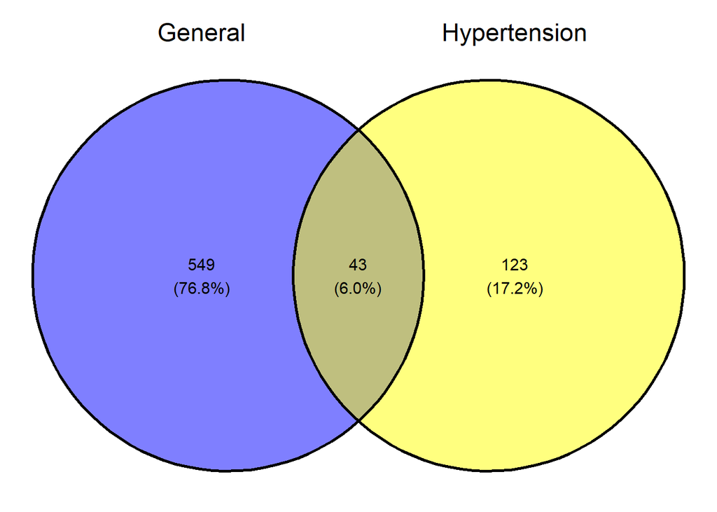

```r
# Assuming 'general_treatments' and 'hypertension_treatments' contain the unique DRUG names as data frames
# Convert them to vectors if they are not already
general_drugs <- general_treatments$DRUG
hypertension_drugs <- hypertension_treatments$DRUG

# Find the intersection (overlap) of treatments between the two tables
overlap_drugs <- intersect(general_drugs, hypertension_drugs)

# Create a named list for the Venn diagram with the count of unique and overlapping drugs
list_of_drugs <- list(
  General = general_drugs,
  Hypertension = hypertension_drugs
)

# Create the Venn diagram
ggvenn(list_of_drugs)
```

#let’s find out the most common anti-hypertension drugs

```r
# Count the number of times each drug is prescribed in the hypertension prescriptions table
drug_counts <- hypertension_prescriptions %>%
  count(DRUG, sort = TRUE) %>%
  collect()

# Print the top 10 most common drugs
print(head(drug_counts, 10))
```

```
## # A tibble: 10 × 2
##    DRUG           n
##    <chr>      <int>
##  1 Metoprolol     2
##  2 Lasix          1
##  3 Lotrel         1
##  4 Tiazac         1
##  5 Nadolol        1
##  6 Timolol        1
##  7 Zestril        1
##  8 timolol        1
##  9 Atenolol       1
## 10 Bosentan       1
```

```r
# Create binary flags for each top drug indicating prescription to a patient
# Create binary flags for prescription of Clonidine
any_clonidine <- prescriptions %>%
  filter(tolower(DRUG) %like% "%clonidine%") %>%  # Ensure the drug name is correctly spelled here
  distinct(SUBJECT_ID) %>%
  mutate(any_clonidine = 1) %>%  # Change the column name to any_clonidine
  collect()

any_atenolol <- prescriptions %>%
  filter(tolower(DRUG) %like% "%atenolol%") %>%
  distinct(SUBJECT_ID) %>%
  mutate(any_atenolol = 1) %>%
  collect()

any_captopril <- prescriptions %>%
  filter(tolower(DRUG) %like% "%captopril%") %>%
  distinct(SUBJECT_ID) %>%
  mutate(any_captopril = 1) %>%
  collect()
```

```r
# Check the first few rows of the dataset to understand its structure
sample_data <- hypertension_prescriptions %>%
  head(10) %>%
  collect()

# Display the column names and a few rows of data
glimpse(sample_data)
```

```
## Rows: 10
## Columns: 1
## $ DRUG <chr> "Lasix", "Lotrel", "Tiazac", "Nadolol", "Timolol", "Zestril", "ti…
```

```r
# Set seed for reproducibility
set.seed(246)

# Collect the data from BigQuery
hypertension_data <- hypertension_goldstandard %>%
  collect()

# Calculate the number of samples for 80%
sample_size <- floor(0.8 * nrow(hypertension_data))

# Sample 80% of the data to create the training set
training <- hypertension_data %>%
  sample_n(sample_size)

# The remaining 20% will be the testing set
testing <- setdiff(hypertension_data, training)
```

#do same from hypterension data

```r
# Join each of the drug indicators to the training set
training <- training %>%
  left_join(any_clonidine, by = "SUBJECT_ID") %>%
  left_join(any_atenolol, by = "SUBJECT_ID") %>%
  left_join(any_captopril, by = "SUBJECT_ID") %>%
  # Replace NA with 0 for patients without a prescription
  mutate(
    any_clonidine = coalesce(any_clonidine, 0),
    any_atenolol = coalesce(any_atenolol, 0),
    any_captopril = coalesce(any_captopril, 0)
  )
```

```r
## getStats(df, predicted, reference)

getStats <- function(df, predicted, reference) {
  df %>%
    select({{ predicted }}, {{ reference }}) %>%
    mutate_all(~ factor(., levels = c(1, 0))) %>%
    table() %>%
    caret::confusionMatrix()
}
```

#left_join and use getStats

```r
stats_clonidine <- training %>%
  collect() %>%
  {print(.$any_clonidine); .} %>%
  getStats(any_clonidine, "HYPERTENSION")
```

```
##  [1] 0 0 0 0 0 0 1 0 0 0 0 0 0 0 0 0 0 0 0 0 0 0 0 0 0 0 0 0 0 0 0 0 0 0 0 0 0 0
## [39] 0 0 0 0 0 0 0 0 0 0 0 0 0 0 0 0 0 0 0 0 1 0 1 0 0 0 0 0 0 0 0 1 0 0 0 0 0 0
## [77] 0 0 0
```

```r
stats_atenolol <- training %>%
  collect() %>%
  {print(.$any_atenolol); .} %>%
  getStats(any_atenolol, "HYPERTENSION")
```

```
##  [1] 0 0 0 0 0 0 0 0 0 0 0 0 0 0 0 0 0 0 0 0 0 0 0 0 0 0 0 0 0 0 0 0 0 0 0 0 0 1
## [39] 0 1 0 0 0 0 0 0 0 0 1 0 0 0 0 0 0 0 0 0 0 0 0 1 0 0 0 0 0 0 1 0 0 0 0 0 0 0
## [77] 0 0 0
```

```r
stats_captopril <- training %>%
  collect() %>%
  {print(.$any_captopril); .} %>%
  getStats(any_captopril, "HYPERTENSION")
```

```
##  [1] 0 0 0 0 0 0 0 0 0 0 0 0 0 0 1 0 0 1 0 0 0 0 0 1 0 0 0 0 0 0 0 0 0 1 0 0 0 1
## [39] 0 0 0 0 0 0 1 0 0 0 1 0 0 0 0 0 0 0 0 0 0 0 0 0 0 0 0 0 0 0 0 0 0 0 0 0 0 0
## [77] 0 0 0
```

```r
# Print the statistics for each drug
print(stats_clonidine)
```

```
## Confusion Matrix and Statistics
##
##              HYPERTENSION
## any_clonidine  1  0
##             1  4  0
##             0 46 29
##
##                Accuracy : 0.4177
##                  95% CI : (0.3077, 0.5341)
##     No Information Rate : 0.6329
##     P-Value [Acc > NIR] : 1
##
##                   Kappa : 0.06
##
##  Mcnemar's Test P-Value : 3.247e-11
##
##             Sensitivity : 0.08000
##             Specificity : 1.00000
##          Pos Pred Value : 1.00000
##          Neg Pred Value : 0.38667
##              Prevalence : 0.63291
##          Detection Rate : 0.05063
##    Detection Prevalence : 0.05063
##       Balanced Accuracy : 0.54000
##
##        'Positive' Class : 1
##
```

```r
print(stats_atenolol)
```

```
## Confusion Matrix and Statistics
##
##             HYPERTENSION
## any_atenolol  1  0
##            1  5  0
##            0 45 29
##
##                Accuracy : 0.4304
##                  95% CI : (0.3194, 0.5467)
##     No Information Rate : 0.6329
##     P-Value [Acc > NIR] : 0.9999
##
##                   Kappa : 0.0754
##
##  Mcnemar's Test P-Value : 5.412e-11
##
##             Sensitivity : 0.10000
##             Specificity : 1.00000
##          Pos Pred Value : 1.00000
##          Neg Pred Value : 0.39189
##              Prevalence : 0.63291
##          Detection Rate : 0.06329
##    Detection Prevalence : 0.06329
##       Balanced Accuracy : 0.55000
##
##        'Positive' Class : 1
##
```

```r
print(stats_captopril)
```

```
## Confusion Matrix and Statistics
##
##              HYPERTENSION
## any_captopril  1  0
##             1  5  2
##             0 45 27
##
##                Accuracy : 0.4051
##                  95% CI : (0.296, 0.5215)
##     No Information Rate : 0.6329
##     P-Value [Acc > NIR] : 1
##
##                   Kappa : 0.0237
##
##  Mcnemar's Test P-Value : 8.993e-10
##
##             Sensitivity : 0.10000
##             Specificity : 0.93103
##          Pos Pred Value : 0.71429
##          Neg Pred Value : 0.37500
##              Prevalence : 0.63291
##          Detection Rate : 0.06329
##    Detection Prevalence : 0.08861
##       Balanced Accuracy : 0.51552
##
##        'Positive' Class : 1
##
```

```r
# Create a logistic regression model for each drug
model_clonidine <- glm(HYPERTENSION ~ any_clonidine, data = training, family = "binomial")

model_atenolol <- glm(HYPERTENSION ~ any_atenolol, data = training, family = "binomial")

model_captopril <- glm(HYPERTENSION ~ any_captopril, data = training, family = "binomial")

# Print the summary of each model
print(summary(model_clonidine))
```

```
##
## Call:
## glm(formula = HYPERTENSION ~ any_clonidine, family = "binomial",
##     data = training)
##
## Coefficients:
##                Estimate Std. Error z value Pr(>|z|)
## (Intercept)      0.4613     0.2371   1.946   0.0517 .
## any_clonidine   16.1047  1199.7724   0.013   0.9893
## ---
## Signif. codes:  0 '***' 0.001 '**' 0.01 '*' 0.05 '.' 0.1 ' ' 1
##
## (Dispersion parameter for binomial family taken to be 1)
##
##     Null deviance: 103.87  on 78  degrees of freedom
## Residual deviance: 100.09  on 77  degrees of freedom
## AIC: 104.09
##
## Number of Fisher Scoring iterations: 15
```

```r
print(summary(model_atenolol))
```

```
##
## Call:
## glm(formula = HYPERTENSION ~ any_atenolol, family = "binomial",
##     data = training)
##
## Coefficients:
##               Estimate Std. Error z value Pr(>|z|)
## (Intercept)     0.4394     0.2381   1.845    0.065 .
## any_atenolol   17.1267  1769.2576   0.010    0.992
## ---
## Signif. codes:  0 '***' 0.001 '**' 0.01 '*' 0.05 '.' 0.1 ' ' 1
##
## (Dispersion parameter for binomial family taken to be 1)
##
##     Null deviance: 103.867  on 78  degrees of freedom
## Residual deviance:  99.099  on 77  degrees of freedom
## AIC: 103.1
##
## Number of Fisher Scoring iterations: 16
```

```r
print(summary(model_captopril))
```

```
##
## Call:
## glm(formula = HYPERTENSION ~ any_captopril, family = "binomial",
##     data = training)
##
## Coefficients:
##               Estimate Std. Error z value Pr(>|z|)
## (Intercept)     0.5108     0.2434   2.098   0.0359 *
## any_captopril   0.4055     0.8714   0.465   0.6417
## ---
## Signif. codes:  0 '***' 0.001 '**' 0.01 '*' 0.05 '.' 0.1 ' ' 1
##
## (Dispersion parameter for binomial family taken to be 1)
##
##     Null deviance: 103.87  on 78  degrees of freedom
## Residual deviance: 103.64  on 77  degrees of freedom
## AIC: 107.64
##
## Number of Fisher Scoring iterations: 4
```

#we know: ● Systolic BP >= 140 mmHg on more than two occasions ● Diastolic BP>= 90 mmHg on more than two occasions

#let’s try a data manipulation to see if we can find the number of patients with hypertension

```r
# Count the number of patients with hypertension
hypertension_count <- hypertension_data %>%
  count(HYPERTENSION) %>%
  collect()

# Print the number of patients with and without hypertension
print(hypertension_count)
```

```
## # A tibble: 2 × 2
##   HYPERTENSION     n
##          <int> <int>
## 1            0    36
## 2            1    63
```

#connect

```r
labevents <- tbl(con, "mimic3_demo.LABEVENTS")
d_labitems <- tbl(con, "mimic3_demo.D_LABITEMS")
chartevents <- tbl(con, "mimic3_demo.CHARTEVENTS")
```

```r
library(tidyr)

library(dplyr)
library(dbplyr)
```

```r
library(DBI)

subject_ids <- hypertension_data %>%
  select(SUBJECT_ID)

systolic_bp_measurements <- chartevents %>%
  filter(ITEMID %in% c(220179, 51, 442, 455, 6701, 220050)) %>%  # Non-invasive systolic BP ITEMIDs
  #searching tables found that these are the ITEMID's for systolic BP
  #examples taken from: https://github.com/MIT-LCP/mimic-code/issues/527
  select(SUBJECT_ID, CHARTTIME, VALUENUM) %>%
  mutate(date = as.Date(CHARTTIME)) %>%
  group_by(SUBJECT_ID, date) %>%
  summarise(max_systolic_bp = max(VALUENUM, na.rm = TRUE)) %>%
  ungroup() %>%
  collect()
diastolic_bp_measurements <- chartevents %>%
  filter(ITEMID %in% c(220051)) %>%
  select(SUBJECT_ID, CHARTTIME, VALUENUM) %>%
  mutate(date = as.Date(CHARTTIME)) %>%
  group_by(SUBJECT_ID, date) %>%
  summarise(max_diastolic_bp = max(VALUENUM, na.rm = TRUE)) %>%
  ungroup() %>%
  collect()
```

#let’s try to summarize

```r
# Assuming systolic_bp_measurements contains the max systolic BP per day for each patient
systolic_hypertension_summary <- systolic_bp_measurements %>%
  group_by(SUBJECT_ID) %>%
  summarise(any_systolic_bp_over_140 = max(max_systolic_bp >= 140, na.rm = TRUE)) %>%
  ungroup() %>%
  collect()
```

#diastolic

```r
# Assuming diastolic_bp_measurements contains the max diastolic BP per day for each patient
diastolic_hypertension_summary <- diastolic_bp_measurements %>%
  group_by(SUBJECT_ID) %>%
  summarise(any_diastolic_bp_over_90 = max(max_diastolic_bp >= 90, na.rm = TRUE)) %>%
  ungroup() %>%
  collect()
```

```r
training_with_systolic <- training %>%
  left_join(systolic_hypertension_summary, by = "SUBJECT_ID") %>%
  mutate(any_systolic_bp_over_140 = coalesce(any_systolic_bp_over_140, 0))

training_with_diastolic <- training %>%
  left_join(diastolic_hypertension_summary, by = "SUBJECT_ID") %>%
  mutate(any_diastolic_bp_over_90 = coalesce(any_diastolic_bp_over_90, 0))
```

#get stats

```r
stats_systolic <- training_with_systolic %>%
  getStats("any_systolic_bp_over_140", "HYPERTENSION")

# Print the statistics for systolic hypertension
print(stats_systolic)
```

```
## Confusion Matrix and Statistics
##
##                         HYPERTENSION
## any_systolic_bp_over_140  1  0
##                        1 40 19
##                        0 10 10
##
##                Accuracy : 0.6329
##                  95% CI : (0.5169, 0.7386)
##     No Information Rate : 0.6329
##     P-Value [Acc > NIR] : 0.5505
##
##                   Kappa : 0.1549
##
##  Mcnemar's Test P-Value : 0.1374
##
##             Sensitivity : 0.8000
##             Specificity : 0.3448
##          Pos Pred Value : 0.6780
##          Neg Pred Value : 0.5000
##              Prevalence : 0.6329
##          Detection Rate : 0.5063
##    Detection Prevalence : 0.7468
##       Balanced Accuracy : 0.5724
##
##        'Positive' Class : 1
##
```

```r
stats_diastolic <- training_with_diastolic %>%
  getStats("any_diastolic_bp_over_90", "HYPERTENSION")

# Print the statistics for diastolic hypertension
print(stats_diastolic)
```

```
## Confusion Matrix and Statistics
##
##                         HYPERTENSION
## any_diastolic_bp_over_90  1  0
##                        1  4  2
##                        0 46 27
##
##                Accuracy : 0.3924
##                  95% CI : (0.2844, 0.5087)
##     No Information Rate : 0.6329
##     P-Value [Acc > NIR] : 1
##
##                   Kappa : 0.0084
##
##  Mcnemar's Test P-Value : 5.417e-10
##
##             Sensitivity : 0.08000
##             Specificity : 0.93103
##          Pos Pred Value : 0.66667
##          Neg Pred Value : 0.36986
##              Prevalence : 0.63291
##          Detection Rate : 0.05063
##    Detection Prevalence : 0.07595
##       Balanced Accuracy : 0.50552
##
##        'Positive' Class : 1
##
```

#let’s dive into this. Systolic BP and Diastolic have sensitivites of 80% nad 8% meaning that 8/10 patients with hypertension were correctly in systolic and diastolic only 8/100 were correctly identified. The true negative rate specificity is high in diastolic and poor in systolic. The PPV were very simmilar around 2/3. NPV is higher in systolic than diastolic. Accuracy is higher in systolic than diastolic. #overall systolic BP appears to be a better predictor of hypertension than diastolic BP

#if wqe are to explore data combinations - what about evaluating both systolic and diastolic

```r
# Combine systolic and diastolic measurements
bp_measurements_combined <- systolic_bp_measurements %>%
  left_join(diastolic_bp_measurements, by = c("SUBJECT_ID", "date")) %>%
  mutate(hypertension_indicator = if_else(max_systolic_bp >= 140 | max_diastolic_bp >= 90, 1, 0)) %>%
  group_by(SUBJECT_ID) %>%
  summarise(hypertension_days = sum(hypertension_indicator, na.rm = TRUE)) %>%
  mutate(hypertension_temporal = if_else(hypertension_days > 2, 1, 0)) %>%
  select(SUBJECT_ID, hypertension_temporal) %>%
  ungroup() %>%
  collect()
```

#binary indicator creation

```r
#head(diagnoses_icd)
# Step 1: Create the hypertension flags based on ICD-9 codes in your remote tibble
hypertension_icd_flags <- diagnoses_icd %>%
  mutate(hypertension_icd = case_when(
    ICD9_CODE %in% c("4010", "4011", "4019") ~ 1,
    TRUE ~ 0
  )) %>%
  group_by(SUBJECT_ID) %>%
  summarise(any_hypertension_icd = max(hypertension_icd, na.rm = TRUE)) %>%
  ungroup() %>%
  # Bring the remote tibble locally
  collect()

# Step 3: Combine systolic and diastolic hypertension summaries
# Make sure systolic_hypertension_summary and diastolic_hypertension_summary are local
training_combined <- training_data %>%
  left_join(systolic_hypertension_summary, by = "SUBJECT_ID") %>%
  left_join(diastolic_hypertension_summary, by = "SUBJECT_ID")

# Step 4: Join the local hypertension ICD-9 flags to the combined dataset
training_combined <- training_combined %>%
  left_join(hypertension_icd_flags, by = "SUBJECT_ID") %>%
  # Replace NA with 0 for any_hypertension_icd
  mutate(any_hypertension_icd = coalesce(any_hypertension_icd, 0))

# Step 5: Check the resulting structure to confirm the new column exists
glimpse(training_combined)
```

```
## Rows: 79
## Columns: 8
## $ SUBJECT_ID               <int> 10114, 40687, 10029, 10089, 10026, 42302, 437…
## $ HYPERTENSION             <int> 1, 1, 1, 0, 1, 1, 1, 1, 1, 0, 0, 1, 1, 1, 1, …
## $ hypertension_4010_min2   <dbl> 0, 0, 0, 0, 0, 0, 0, 0, 0, 0, 0, 0, 0, 0, 0, …
## $ hypertension_4011_min2   <dbl> 0, 0, 0, 0, 0, 0, 0, 0, 0, 0, 0, 0, 0, 0, 0, …
## $ hypertension_4019_min2   <dbl> 0, 0, 0, 0, 0, 0, 0, 0, 0, 0, 0, 0, 0, 0, 0, …
## $ any_systolic_bp_over_140 <int> 1, 1, 1, 1, 1, 1, 1, 1, 1, 0, 1, 1, 0, 0, 1, …
## $ any_diastolic_bp_over_90 <int> NA, NA, NA, NA, NA, NA, 1, NA, 0, NA, NA, NA,…
## $ any_hypertension_icd     <dbl> 0, 1, 0, 1, 1, 0, 0, 1, 0, 0, 0, 0, 0, 0, 0, …
```

#stats

```r
# Get the statistics for the ICD-9 codes
stats_icd <- training_combined %>%
  getStats("any_hypertension_icd", "HYPERTENSION")

# Print the statistics for the ICD-9 codes
print(stats_icd)
```

```
## Confusion Matrix and Statistics
##
##                     HYPERTENSION
## any_hypertension_icd  1  0
##                    1 28  2
##                    0 22 27
##
##                Accuracy : 0.6962
##                  95% CI : (0.5825, 0.7947)
##     No Information Rate : 0.6329
##     P-Value [Acc > NIR] : 0.1464654
##
##                   Kappa : 0.4289
##
##  Mcnemar's Test P-Value : 0.0001052
##
##             Sensitivity : 0.5600
##             Specificity : 0.9310
##          Pos Pred Value : 0.9333
##          Neg Pred Value : 0.5510
##              Prevalence : 0.6329
##          Detection Rate : 0.3544
##    Detection Prevalence : 0.3797
##       Balanced Accuracy : 0.7455
##
##        'Positive' Class : 1
##
```

```r
# Get the statistics for the combined BP measurements
stats_combined <- training_combined %>%
  left_join(bp_measurements_combined, by = "SUBJECT_ID") %>%
  getStats("hypertension_temporal", "HYPERTENSION")

# Print the statistics for the combined BP measurements
print(stats_combined)
```

```
## Confusion Matrix and Statistics
##
##                      HYPERTENSION
## hypertension_temporal  1  0
##                     1 22  7
##                     0 28 20
##
##                Accuracy : 0.5455
##                  95% CI : (0.4279, 0.6594)
##     No Information Rate : 0.6494
##     P-Value [Acc > NIR] : 0.9773214
##
##                   Kappa : 0.1533
##
##  Mcnemar's Test P-Value : 0.0007232
##
##             Sensitivity : 0.4400
##             Specificity : 0.7407
##          Pos Pred Value : 0.7586
##          Neg Pred Value : 0.4167
##              Prevalence : 0.6494
##          Detection Rate : 0.2857
##    Detection Prevalence : 0.3766
##       Balanced Accuracy : 0.5904
##
##        'Positive' Class : 1
##
```

```r
#training_with_hypertension_icd
```

#actually let’s use this - we have too many objects in a cluttered environment

```r
training_combined$any_hypertension_icd <- ifelse(is.na(training_combined$any_hypertension_icd), 0, training_combined$any_hypertension_icd)
```

```r
stats_combined <- getStats(training_combined, "any_hypertension_icd", "HYPERTENSION")

# Print the statistics for the combined BP measurements
print(stats_combined)
```

```
## Confusion Matrix and Statistics
##
##                     HYPERTENSION
## any_hypertension_icd  1  0
##                    1 28  2
##                    0 22 27
##
##                Accuracy : 0.6962
##                  95% CI : (0.5825, 0.7947)
##     No Information Rate : 0.6329
##     P-Value [Acc > NIR] : 0.1464654
##
##                   Kappa : 0.4289
##
##  Mcnemar's Test P-Value : 0.0001052
##
##             Sensitivity : 0.5600
##             Specificity : 0.9310
##          Pos Pred Value : 0.9333
##          Neg Pred Value : 0.5510
##              Prevalence : 0.6329
##          Detection Rate : 0.3544
##    Detection Prevalence : 0.3797
##       Balanced Accuracy : 0.7455
##
##        'Positive' Class : 1
##
```

#taken together the sensitivity is 0.56 so true positives slightly higher than 1/2. Specificity is very high - correctly identify negative hypertension with combined icd codes. PPV is very high and NPV is ~0.5. This means that the combined ICD codes are very good at identifying true negatives but not so good at identifying true positives.

#Data combination 2 #we know diastolic is very insensitive - what if we combined with prescription of any of our top three

```r
# Add a column to indicate the combination of diastolic blood pressure over 90 and prescription
training_with_diastolic <- training_with_diastolic %>%
  mutate(diastolic_bp_and_prescription = case_when(
    any_diastolic_bp_over_90 == 1 & (any_clonidine == 1 | any_atenolol == 1 | any_captopril == 1) ~ 1,
    TRUE ~ 0
  ))

# Convert diastolic_bp_and_prescription to factor or character
training_with_diastolic <- training_with_diastolic %>%
  mutate(diastolic_bp_and_prescription = as.factor(diastolic_bp_and_prescription))


# Get statistics for the combined variable
stats_diastolic_and_prescription <- getStats(training_with_diastolic, "diastolic_bp_and_prescription", "HYPERTENSION")
```

#print

```r
# Print the statistics for the combined variable
print(stats_diastolic_and_prescription)
```

```
## Confusion Matrix and Statistics
##
##                              HYPERTENSION
## diastolic_bp_and_prescription  1  0
##                             1  2  0
##                             0 48 29
##
##                Accuracy : 0.3924
##                  95% CI : (0.2844, 0.5087)
##     No Information Rate : 0.6329
##     P-Value [Acc > NIR] : 1
##
##                   Kappa : 0.0297
##
##  Mcnemar's Test P-Value : 1.17e-11
##
##             Sensitivity : 0.04000
##             Specificity : 1.00000
##          Pos Pred Value : 1.00000
##          Neg Pred Value : 0.37662
##              Prevalence : 0.63291
##          Detection Rate : 0.02532
##    Detection Prevalence : 0.02532
##       Balanced Accuracy : 0.52000
##
##        'Positive' Class : 1
##
```

#Based on the statistics the combination results in a very poor indicator of hypertension. The sensitivity went down. The specificity and PPV are very high - this means that only about 4% of cases are caught though the actual positives found are accurate.